# assignment 3

2023-10-22

# Assignment 3

## Load in the appropriate libraries

```r
library("sqldf")
library(tidyverse)
library(RODBC)
```

## Connect to SQL

```r
db_conn <- odbcConnect("myDatabase", rows_at_time = 1)
```

## Question 1: Which geographic regions generate the most sales?

### Extract the data from SQL

Save SQL query in variable “salesQuery”, then use the sqlQuery function to execute the query and produce the sales_df dataframe.

I used SalesOrderHeader TotalDue instead of SalesOrderDetail LineTotal but I verified that TotalDue also reflects sales and my result matches the example on the assignment.

```r
salesQuery <- "SELECT Sales.SalesOrderHeader.TotalDue, Sales.SalesTerritory.[Group] as 'geographic_region'
FROM Sales.SalesTerritory
LEFT JOIN Sales.SalesOrderHeader
ON Sales.SalesOrderHeader.TerritoryID = Sales.SalesTerritory.TerritoryID"

sales_df <- sqlQuery(db_conn, salesQuery, stringsAsFactors = FALSE)
head(sales_df)
```

```
##     TotalDue geographic_region
## 1 23153.2339     North America
## 2  1457.3288     North America
## 3 36865.8012     North America
## 4 32474.9324     North America
## 5   472.3108     North America
## 6 27510.4109     North America
```

Check for nulls

```r
summary(sales_df)
```

```
##     TotalDue         geographic_region
##  Min.   :     1.52   Length:31465
##  1st Qu.:    62.95   Class :character
##  Median :   865.20   Mode  :character
##  Mean   :  3916.00
##  3rd Qu.:  2615.49
##  Max.   :187487.83
```

```r
unique(sales_df$geographic_region)
```

```
## [1] "North America" "Europe"        "Pacific"
```

### Create Pie Chart

group by region and rename the columns. The code for grouping the df was found on sparkbyexamples.com. All code sources are linked at the bottom of this assignment.

```r
grouped_sales <- aggregate(sales_df$TotalDue, by = list(sales_df$geographic_region), FUN = sum)
grouped_sales <- rename(grouped_sales, "geographic_region" = "Group.1")
grouped_sales <- rename(grouped_sales, "total_sales" = "x")

grouped_sales
```

```
##   geographic_region total_sales
## 1            Europe    22173618
## 2     North America    89228792
## 3           Pacific    11814376
```

calculate the percentage of sales for each region, and create the labels for the pie chart. The paste() function was found on r-bloggers.com.

```r
grouped_sales$percentage <- with(grouped_sales, round((total_sales/(22173618+89228792+11814376))*100), 0)

grouped_sales$labels <- with(grouped_sales, paste(geographic_region,", ",as.character(percentage),"%", sep=""))

grouped_sales
```

```
##   geographic_region total_sales percentage             labels
## 1            Europe    22173618         18        Europe, 18%
## 2     North America    89228792         72 North America, 72%
## 3           Pacific    11814376         10       Pacific, 10%
```

I found two methods for creating pie charts online. Both were found on r-graph-gallery.com

#### Method One

Extract the labels and values for each pie slice from the dataframe as vectors and create the chart

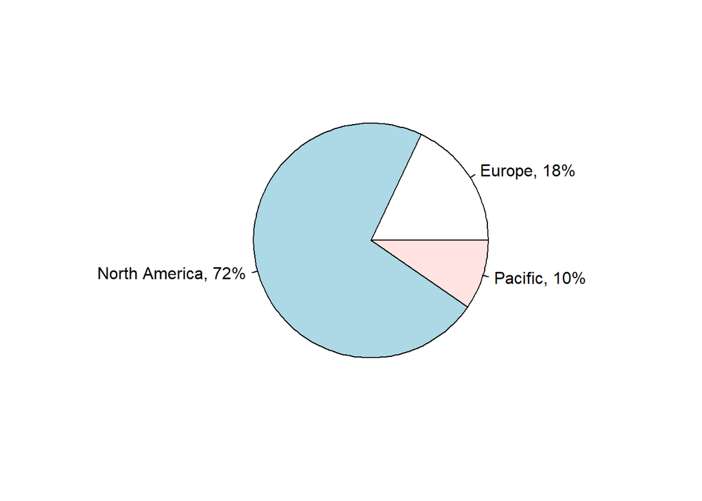

```r
vector_labels = grouped_sales[["labels"]]
vector_count = grouped_sales[["total_sales"]]

pie(vector_count, labels=vector_labels)
```

#### Method Two

Determine position of labels

```r
grouped_sales<- grouped_sales %>%
  arrange(desc(labels)) %>%
  mutate(prop = total_sales / sum(grouped_sales$total_sales) *100) %>%
  mutate(ypos = cumsum(prop) - 0.6*prop)
```

Create the pie chart

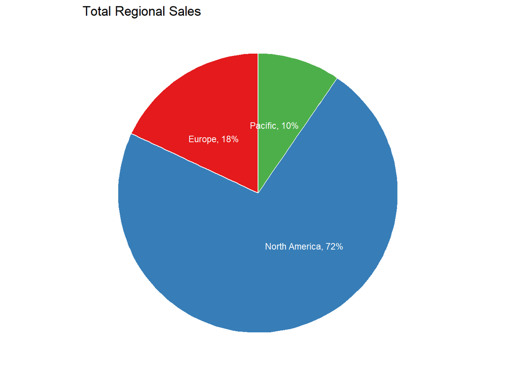

```r
ggplot(grouped_sales, aes(x="", y=prop, fill=labels)) +
  geom_bar(stat="identity", width=1, color="white") +
  coord_polar("y", start=0) +
  theme_void() +
  theme(legend.position="none") +
  geom_text(aes(y = ypos, label = labels), color = "white", size=3) +
  scale_fill_brewer(palette="Set1") +
  labs(title="Total Regional Sales")
```

North America generates the most sales at 72%.

## Question Two: What are the most profitable products?

### Extract the data from SQL

```r
productQuery <- "SELECT Production.Product.Name, Sales.SalesOrderDetail.OrderQty,
Production.Product.StandardCost, Sales.SalesOrderDetail.LineTotal
FROM Sales.SalesOrderDetail
LEFT JOIN Production.Product
ON Sales.SalesOrderDetail.ProductID = Production.Product.ProductID"

product_df <- sqlQuery(db_conn, productQuery, stringsAsFactors = FALSE)

head(product_df)
```

```
##                      Name OrderQty StandardCost LineTotal
## 1  Mountain-100 Black, 42        1     1898.094  2024.994
## 2  Mountain-100 Black, 44        3     1898.094  6074.982
## 3  Mountain-100 Black, 48        1     1898.094  2024.994
## 4 Mountain-100 Silver, 38        1     1912.154  2039.994
## 5 Mountain-100 Silver, 42        1     1912.154  2039.994
## 6 Mountain-100 Silver, 44        2     1912.154  4079.988
```

### Prepare Data for Plotting

Calculate profit

```r
product_df$Profit <- with(product_df, (LineTotal - StandardCost*OrderQty))

head(product_df)
```

```
##                      Name OrderQty StandardCost LineTotal   Profit
## 1  Mountain-100 Black, 42        1     1898.094  2024.994 126.8996
## 2  Mountain-100 Black, 44        3     1898.094  6074.982 380.6988
## 3  Mountain-100 Black, 48        1     1898.094  2024.994 126.8996
## 4 Mountain-100 Silver, 38        1     1912.154  2039.994 127.8396
## 5 Mountain-100 Silver, 42        1     1912.154  2039.994 127.8396
## 6 Mountain-100 Silver, 44        2     1912.154  4079.988 255.6792
```

Group by product

This method of grouping was adapted from stackoverflow. It originally used summarise_each() and funs() but upon receiving warnings of these functions being deprecated I followed the warning’s suggestion and used across() and list().

```r
grouped_product <- product_df %>%
  group_by(Name) %>%
  summarise(across(everything(), list(sum = sum)))

head(grouped_product)
```

```
## # A tibble: 6 × 5
##   Name                   OrderQty_sum StandardCost_sum LineTotal_sum Profit_sum
##   <chr>                         <int>            <dbl>         <dbl>      <dbl>
## 1 AWC Logo Cap                   8311           23411.        51229.     -6302.
## 2 All-Purpose Bike Stand          249           14807.        39591      24784.
## 3 Bike Wash - Dissolver          3319            3946.        18407.      8539.
## 4 Cable Lock                     1087            2681.        16240.      5031.
## 5 Chain                           774            2247.         9378.      2422.
## 6 Classic Vest, L                 207            4774.        12840.      7924.
```

Sort by profit and grab the top 10 products to plot

```r
grouped_product <- grouped_product[order(grouped_product$Profit_sum,decreasing=TRUE),]
profitable_prods <- head(grouped_product, 10)

profitable_prods
```

```
## # A tibble: 10 × 5
##    Name                   OrderQty_sum StandardCost_sum LineTotal_sum Profit_sum
##    <chr>                         <int>            <dbl>         <dbl>      <dbl>
##  1 Mountain-200 Black, 42         2664         1473582.      4009495.    674217.
##  2 Mountain-200 Black, 38         2977         1567481.      4400593.    673444.
##  3 Mountain-200 Black, 46         2111         1325848.      3309673.    666741.
##  4 Mountain-200 Silver, …         2394         1384588.      3693678.    663785.
##  5 Mountain-200 Silver, …         2216         1333963.      3434257.    629644.
##  6 Mountain-200 Silver, …         2234         1316244.      3438479.    611085.
##  7 Road-150 Red, 48                493          888059.      1540803.    470355.
##  8 Road-150 Red, 62                600         1020508.      1769097.    466320.
##  9 Road-150 Red, 52                458          820749.      1415564.    421111.
## 10 Road-150 Red, 56                664         1031365.      1847819.    406079.
```

Grab only the columns to plot and rename them

```r
sub <- profitable_prods %>%
  select(1,4,5)

sub <- rename(sub, "Total Sales" = "LineTotal_sum") %>%
  rename("Total Profit" = "Profit_sum")

head(sub)
```

```
## # A tibble: 6 × 3
##   Name                    `Total Sales` `Total Profit`
##   <chr>                           <dbl>          <dbl>
## 1 Mountain-200 Black, 42       4009495.        674217.
## 2 Mountain-200 Black, 38       4400593.        673444.
## 3 Mountain-200 Black, 46       3309673.        666741.
## 4 Mountain-200 Silver, 38      3693678.        663785.
## 5 Mountain-200 Silver, 46      3434257.        629644.
## 6 Mountain-200 Silver, 42      3438479.        611085.
```

Melt the data so that Total Sales and Total Profit can be plotted as a stacked bar chart. The general methodology for creating this bar chart including the melting function was found on stackoverflow.com

```r
product_long <- tidyr::pivot_longer(sub, cols=c('Total Sales', 'Total Profit'),
                                    names_to='Variable', values_to='Value')

head(product_long)
```

```
## # A tibble: 6 × 3
##   Name                   Variable        Value
##   <chr>                  <chr>           <dbl>
## 1 Mountain-200 Black, 42 Total Sales  4009495.
## 2 Mountain-200 Black, 42 Total Profit  674217.
## 3 Mountain-200 Black, 38 Total Sales  4400593.
## 4 Mountain-200 Black, 38 Total Profit  673444.
## 5 Mountain-200 Black, 46 Total Sales  3309673.
## 6 Mountain-200 Black, 46 Total Profit  666741.
```

Create the bar chart. Again, this code was adapted from stackoverflow.com. The scale_fill_manual specification was found on learn.saylor.org, and the scale_x_continuous code was adapted from rpubs.com.

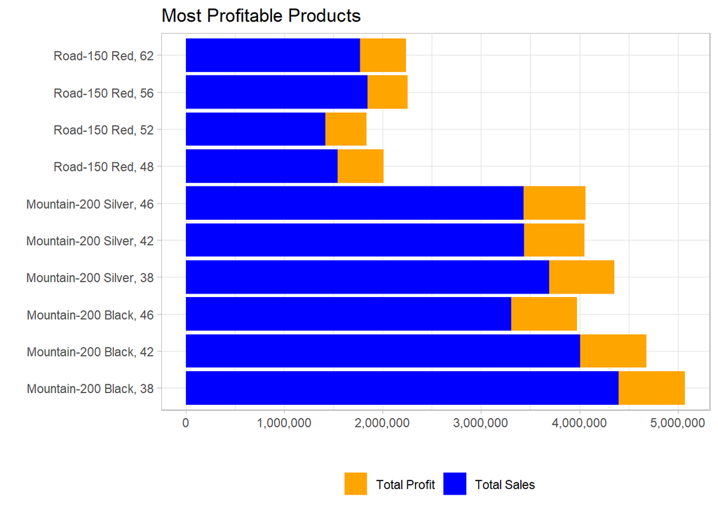

```r
ggplot(product_long, aes(x = Value, y = Name, fill = Variable)) +
  geom_bar(stat = "identity", position = "stack") +
  labs(title = "Most Profitable Products",
       x = "",
       y = "",
       fill = "") +
  scale_fill_manual(values = c("Total Profit" = "orange", "Total Sales" = "blue")) +
  theme_light() +
  theme(legend.position='bottom') +
  scale_x_continuous(labels = scales::comma)
```

It’s a bit hard to see in the graph, but the most profitable product is “Mountain-200 Black, 42.”

```r
top_prod <- profitable_prods[1,1]
as.character(top_prod)
```

```
## [1] "Mountain-200 Black, 42"
```

## Code Sources

- [Grouping 1](https://sparkbyexamples.com/r-programming/group-by-count-in-r/)
- [Grouping 2](https://stackoverflow.com/questions/8212699/group-by-multiple-columns-and-sum-other-multiple-columns)
- [ggplot pie chart](https://r-graph-gallery.com/piechart-ggplot2.html)
- [pie() pie chart](https://r-graph-gallery.com/131-pie-plot-with-r.html)
- [paste()](https://www.r-bloggers.com/2022/08/r-program-to-concatenate-two-strings/)
- [melting/plotting two numerical vars in a bar chart](https://stackoverflow.com/questions/42820677/ggplot-bar-plot-side-by-side-using-two-variables)
- [custom bar colours](https://learn.saylor.org/mod/book/view.php?id=58485&chapterid=45033)
- [continuous x axis](https://rpubs.com/techanswers88/remove-scientific-notation-in-ggplot)